# Practical Machine Learning Assignment

27th December 2015

## Data

Reading in the data and partitioning the training dataset into a model training (75%) and a model test dataset (25%), this leaves the ‘test’ csv file for the best performing model.

```r
set.seed(12345)
#read in training dataset
train <- read.csv('pml-training.csv')
# create training set indexes with 75% of data
inTrain <- createDataPartition(y=train$classe,p=0.75, list=FALSE)
# subset data to training
training <- train[inTrain,]
# subset data (the rest) to test
testing <- train[-inTrain,]
# dimension of original and training dataset
rbind("original dataset" = dim(train),"training set" = dim(training))
```

```
##                   [,1] [,2]
## original dataset 19622  160
## training set     14718  160
```

### Exploratory Data Analysis

Table 1 in the Appendix shows the summary table for the training dataset. The following features are noticeable:

1. there are more than 14,000 observations which have NA’s in the vast majority of measurements.
2. There are measurements which appear to be highly correlated:
   1. Covariates beginning with var_ and those beginning with stddev_. These are variance and standard deviation measurements.
   2. Covariates ending with _x, _y, _z. These are measurements in 3 dimensions.

The following plots show the correlations between these identified covariates:

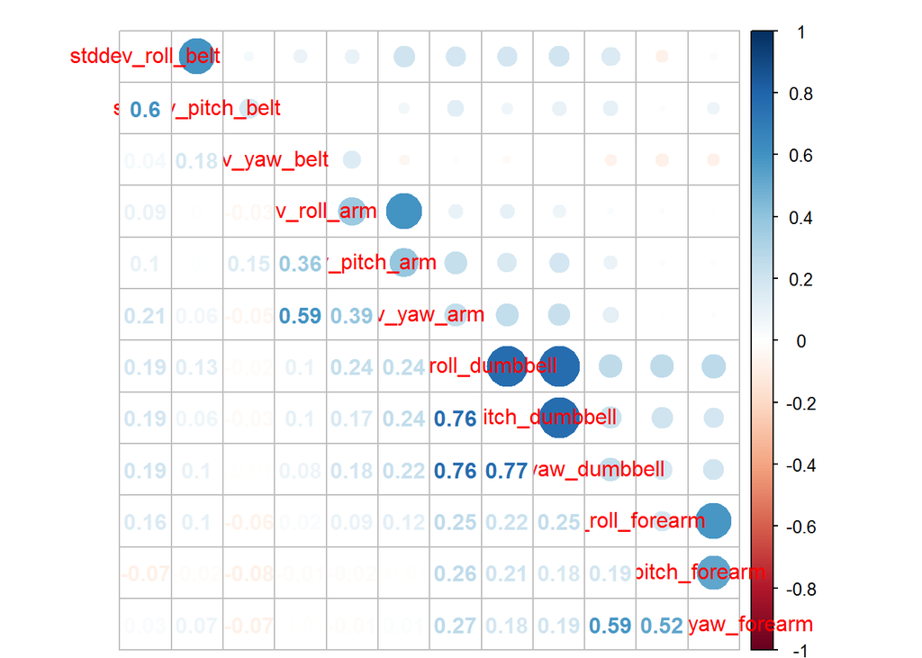

```r
#keep predictors
var_covar <- grep("^[Vv][a][r][_]",names(training), value=TRUE)
std_covar <- grep("^[Ss][t][d]",names(training), value=TRUE)
avg_covar <- grep("^[Aa][v][g]",names(training), value=TRUE)
x_covar <- grep("x$",names(training), value=TRUE)
y_covar <- grep("y$",names(training), value=TRUE)
z_covar <- grep("z$",names(training), value=TRUE)

#plot the correlation matrix for these subsets
M <- cor(training[,c(std_covar)],use="pairwise.complete.obs")
corrplot.mixed(M)
```

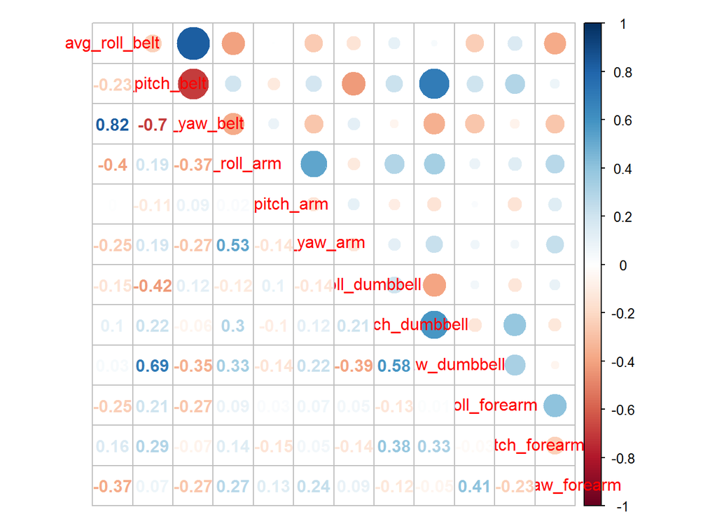

```r
M_Avg <- cor(training[,c(avg_covar)],use="pairwise.complete.obs")
corrplot.mixed(M_Avg)
```

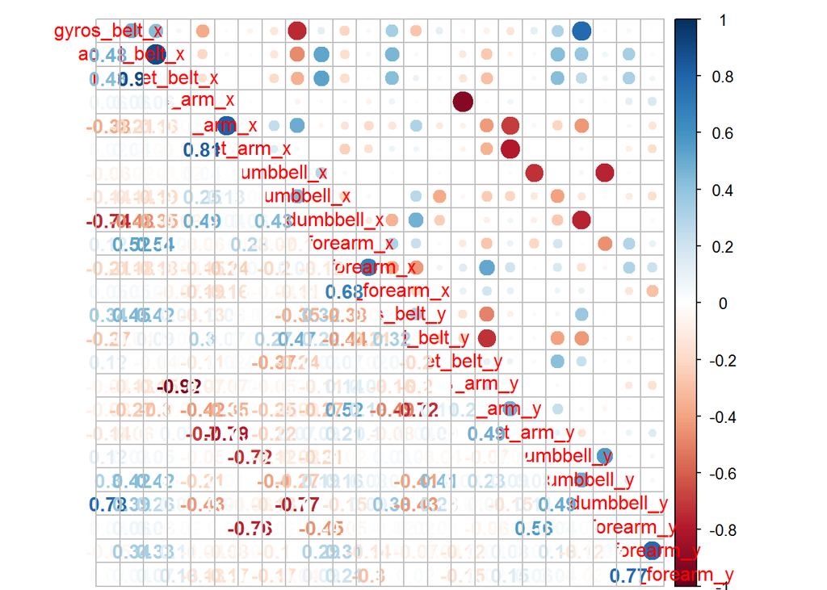

```r
M_XY <- cor(training[,c(x_covar,y_covar)],use="pairwise.complete.obs")
corrplot.mixed(M_XY)
```

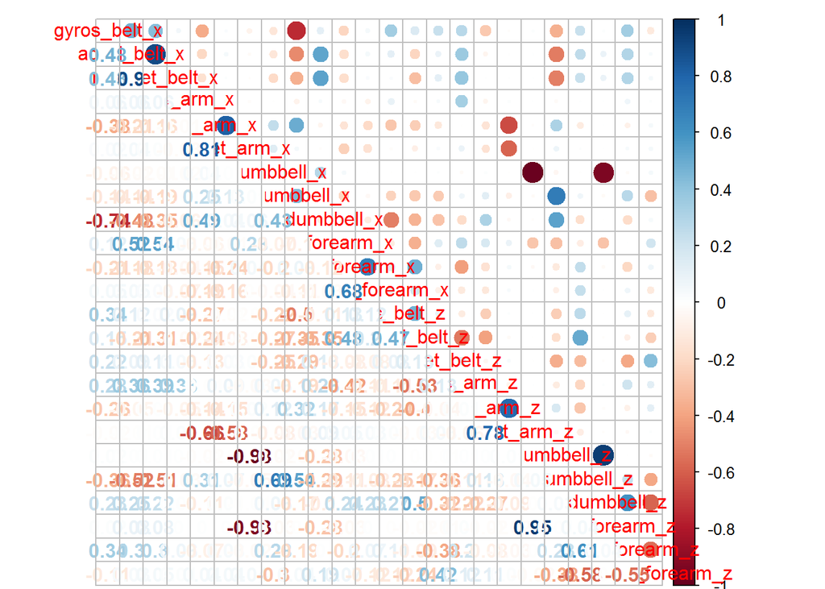

```r
M_XZ <- cor(training[,c(x_covar,z_covar)],use="pairwise.complete.obs")
corrplot.mixed(M_XZ)
```

Some of the covariates are highly correlated (>80%) so preprocessing of the data would be advisable.

## Identifying Covariates with near zero variance

Table 2 in the appendix shows the full table of variables with the associated metrics for the near zero variance test.

This shows that all covariates have more than 1 value associated with it but that there are a number of covariates which are close to zero variance. For prediction purposes these will be removed.

```
##                                      [,1] [,2]
## training dataset removing near zero 14718  105
```

There are still a large number of covariates with greater than 14,000 observations with NA values, this represents greater than 95% of observations are unknown for these covariates. These covariates could be imputed from non-missing variables.

### Method

For each model assess by using the misclassification table on the partitioned test set.

```
##
## Call:
##  randomForest(x = x, y = y, mtry = param$mtry)
##                Type of random forest: classification
##                      Number of trees: 500
## No. of variables tried at each split: 50
##
##         OOB estimate of  error rate: 0.4%
## Confusion matrix:
##      A    B    C    D    E  class.error
## A 4183    0    0    1    1 0.0004778973
## B   11 2834    3    0    0 0.0049157303
## C    6    8 2551    2    0 0.0062329568
## D    3    0   13 2395    1 0.0070480929
## E    2    2    0    6 2696 0.0036954915
```

```
##
##        A    B    C    D    E
##   A 1395    0    0    0    0
##   B    3  943    3    0    0
##   C    3    4  848    0    0
##   D    1    0    3  800    0
##   E    1    0    0    3  897
```

```
## rf variable importance
##
##   only 20 most important variables shown (out of 99)
##
##                      Overall
## num_window           100.000
## roll_belt             69.354
## amplitude_yaw_arm     42.601
## yaw_belt              37.524
## magnet_dumbbell_z     27.372
## magnet_dumbbell_y     25.721
## pitch_belt            20.453
## pitch_forearm         16.162
## roll_dumbbell         14.889
## roll_forearm          14.820
## var_accel_dumbbell    12.761
## magnet_dumbbell_x     11.982
## total_accel_dumbbell  11.009
## accel_dumbbell_y       9.623
## accel_belt_z           8.268
## accel_forearm_x        7.978
## accel_dumbbell_z       7.891
## var_roll_belt          6.373
## var_accel_arm          5.907
## magnet_belt_z          5.788
```

The table above shows the variable importance from the Random Forest classification fit.

### Test Dataset

```r
set.seed(12345)
#read in test dataset
test <- read.csv('pml-testing.csv')

#remove near zero factors
testnz <- test[,!nz$nzv]

#Impute missing values
model_test <- testnz[,c(6:ncol(testnz))]
names(model_test)
```

```
##   [1] "num_window"               "roll_belt"
##   [3] "pitch_belt"               "yaw_belt"
##   [5] "total_accel_belt"         "max_roll_belt"
##   [7] "max_picth_belt"           "min_roll_belt"
##   [9] "min_pitch_belt"           "amplitude_roll_belt"
##  [11] "amplitude_pitch_belt"     "var_total_accel_belt"
##  [13] "avg_roll_belt"            "stddev_roll_belt"
##  [15] "var_roll_belt"            "avg_pitch_belt"
##  [17] "stddev_pitch_belt"        "var_pitch_belt"
##  [19] "avg_yaw_belt"             "stddev_yaw_belt"
##  [21] "var_yaw_belt"             "gyros_belt_x"
##  [23] "gyros_belt_y"             "gyros_belt_z"
##  [25] "accel_belt_x"             "accel_belt_y"
##  [27] "accel_belt_z"             "magnet_belt_x"
##  [29] "magnet_belt_y"            "magnet_belt_z"
```

[output cut: 35 more lines]

```r
names(model_traindata)
```

```
##   [1] "num_window"               "roll_belt"
##   [3] "pitch_belt"               "yaw_belt"
##   [5] "total_accel_belt"         "max_roll_belt"
##   [7] "max_picth_belt"           "min_roll_belt"
##   [9] "min_pitch_belt"           "amplitude_roll_belt"
##  [11] "amplitude_pitch_belt"     "var_total_accel_belt"
##  [13] "avg_roll_belt"            "stddev_roll_belt"
##  [15] "var_roll_belt"            "avg_pitch_belt"
##  [17] "stddev_pitch_belt"        "var_pitch_belt"
##  [19] "avg_yaw_belt"             "stddev_yaw_belt"
##  [21] "var_yaw_belt"             "gyros_belt_x"
##  [23] "gyros_belt_y"             "gyros_belt_z"
##  [25] "accel_belt_x"             "accel_belt_y"
##  [27] "accel_belt_z"             "magnet_belt_x"
##  [29] "magnet_belt_y"            "magnet_belt_z"
```

[output cut: 36 more lines]

```r
Impute_test <- predict(preProcValues, model_test[,-ncol(model_test)] )

model_test$pred <- predict(fit1,Impute_test)

Finaltest <- model_test[,c("pred")]
```

According to the model the 20 test observations have been allocated to:

A : 7 B : 8 C : 1 D : 1 E : 3

### Appendix

Table 1: Summary table of training dataset

```
##        X            user_name    raw_timestamp_part_1 raw_timestamp_part_2
##  Min.   :    2   adelmo  :2947   Min.   :1.322e+09    Min.   :   294
##  1st Qu.: 4895   carlitos:2337   1st Qu.:1.323e+09    1st Qu.:254682
##  Median : 9810   charles :2617   Median :1.323e+09    Median :500344
##  Mean   : 9806   eurico  :2301   Mean   :1.323e+09    Mean   :502309
##  3rd Qu.:14722   jeremy  :2532   3rd Qu.:1.323e+09    3rd Qu.:752313
##  Max.   :19620   pedro   :1984   Max.   :1.323e+09    Max.   :998801
##
##           cvtd_timestamp   num_window      roll_belt
##  28/11/2011 14:14:1160   Min.   :  1.0   Min.   :-28.9
##  05/12/2011 11:24:1123   1st Qu.:220.0   1st Qu.:  1.1
##  30/11/2011 17:11:1088   Median :422.0   Median :114.0
##  05/12/2011 11:25:1060   Mean   :429.6   Mean   : 64.6
##  02/12/2011 13:34:1037   3rd Qu.:643.8   3rd Qu.:123.0
##  02/12/2011 14:58:1021   Max.   :864.0   Max.   :162.0
##  (Other)         :8229
##    pitch_belt          yaw_belt       total_accel_belt max_roll_belt
##  Min.   :-54.9000   Min.   :-180.00   Min.   : 0.00    Min.   :-94.300
##  1st Qu.:  1.7100   1st Qu.: -88.30   1st Qu.: 3.00    1st Qu.:-88.000
##  Median :  5.2700   Median : -12.70   Median :17.00    Median : -4.900
##  Mean   :  0.2132   Mean   : -10.86   Mean   :11.33    Mean   : -5.743
##  3rd Qu.: 14.9000   3rd Qu.:  13.60   3rd Qu.:18.00    3rd Qu.: 20.075
##  Max.   : 60.3000   Max.   : 179.00   Max.   :29.00    Max.   :180.000
##                                                        NA's   :14408
##  max_picth_belt  min_roll_belt     min_pitch_belt  amplitude_roll_belt
##  Min.   : 3.00   Min.   :-180.00   Min.   : 0.00   Min.   :  0.000
##  1st Qu.: 5.00   1st Qu.: -88.47   1st Qu.: 3.00   1st Qu.:  0.325
##  Median :18.00   Median :  -8.00   Median :16.00   Median :  1.000
##  Mean   :12.97   Mean   : -10.20   Mean   :10.72   Mean   :  4.454
##  3rd Qu.:19.00   3rd Qu.:  13.28   3rd Qu.:17.00   3rd Qu.:  2.197
##  Max.   :30.00   Max.   : 173.00   Max.   :23.00   Max.   :360.000
##  NA's   :14408   NA's   :14408     NA's   :14408   NA's   :14408
##  amplitude_pitch_belt var_total_accel_belt avg_roll_belt
##  Min.   : 0.000       Min.   : 0.000       Min.   :-27.40
##  1st Qu.: 1.000       1st Qu.: 0.100       1st Qu.:  1.10
##  Median : 1.000       Median : 0.200       Median :116.40
##  Mean   : 2.258       Mean   : 0.983       Mean   : 67.94
##  3rd Qu.: 2.000       3rd Qu.: 0.300       3rd Qu.:124.00
##  Max.   :12.000       Max.   :16.500       Max.   :157.40
##  NA's   :14408        NA's   :14408        NA's   :14408
```

[output cut: 177 more lines]

```
##  Min.   :-498.00   Min.   :-632.0   Min.   :-391.00   Min.   :-1280.0
##  1st Qu.:-179.00   1st Qu.:  59.0   1st Qu.:-181.00   1st Qu.: -617.0
##  Median : -57.00   Median : 201.0   Median : -40.00   Median : -383.0
##  Mean   : -62.43   Mean   : 164.2   Mean   : -55.13   Mean   : -315.4
##  3rd Qu.:  76.00   3rd Qu.: 313.0   3rd Qu.:  26.00   3rd Qu.:  -78.0
##  Max.   : 477.00   Max.   : 923.0   Max.   : 291.00   Max.   :  672.0
##
##  magnet_forearm_y    magnet_forearm_z classe
##  Min.   :-892.0000   Min.   :-973.0   A:4185
##  1st Qu.:  -0.0922   1st Qu.: 191.0   B:2848
##  Median : 589.0000   Median : 512.0   C:2567
##  Mean   : 381.0351   Mean   : 393.9   D:2412
##  3rd Qu.: 737.0000   3rd Qu.: 653.0   E:2706
##  Max.   :1480.0000   Max.   :1090.0
##
```

Table 2: Variables with Near Zero Variance

```
##                            freqRatio percentUnique zeroVar   nzv
## X                           1.000000  100.00000000   FALSE FALSE
## user_name                   1.126099    0.04076641   FALSE FALSE
## raw_timestamp_part_1        1.031250    5.68691398   FALSE FALSE
## raw_timestamp_part_2        1.000000   89.04063052   FALSE FALSE
## cvtd_timestamp              1.032947    0.13588803   FALSE FALSE
## new_window                 46.477419    0.01358880   FALSE  TRUE
## num_window                  1.031250    5.82280201   FALSE FALSE
## roll_belt                   1.090511    7.67767360   FALSE FALSE
## pitch_belt                  1.026490   11.62522082   FALSE FALSE
## yaw_belt                    1.077922   12.39298818   FALSE FALSE
## total_accel_belt            1.064708    0.19703764   FALSE FALSE
## kurtosis_roll_belt       2401.333333    2.07229243   FALSE  TRUE
## kurtosis_picth_belt       626.434783    1.73936676   FALSE  TRUE
## kurtosis_yaw_belt          46.477419    0.01358880   FALSE  TRUE
## skewness_roll_belt       2881.600000    2.06549803   FALSE  TRUE
## skewness_roll_belt.1      626.434783    1.82769398   FALSE  TRUE
## skewness_yaw_belt          46.477419    0.01358880   FALSE  TRUE
## max_roll_belt               1.000000    1.14145944   FALSE FALSE
## max_picth_belt              1.352941    0.14268243   FALSE FALSE
## max_yaw_belt              654.909091    0.42125289   FALSE  TRUE
## min_roll_belt               1.111111    1.05992662   FALSE FALSE
## min_pitch_belt              2.175000    0.10871042   FALSE FALSE
## min_yaw_belt              654.909091    0.42125289   FALSE  TRUE
## amplitude_roll_belt         1.125000    0.81532817   FALSE FALSE
## amplitude_pitch_belt        2.962963    0.08153282   FALSE FALSE
## amplitude_yaw_belt         48.511785    0.02717761   FALSE  TRUE
## var_total_accel_belt        1.377049    0.36689768   FALSE FALSE
## avg_roll_belt               1.166667    1.09389863   FALSE FALSE
## stddev_roll_belt            1.075000    0.41445849   FALSE FALSE
## var_roll_belt               1.540984    0.54355211   FALSE FALSE
## avg_pitch_belt              1.000000    1.21619785   FALSE FALSE
## stddev_pitch_belt           1.170213    0.25139285   FALSE FALSE
## var_pitch_belt              1.242857    0.36689768   FALSE FALSE
## avg_yaw_belt                1.250000    1.35208588   FALSE FALSE
## stddev_yaw_belt             1.911765    0.34651447   FALSE FALSE
## var_yaw_belt                1.243243    0.85609458   FALSE FALSE
## gyros_belt_x                1.056365    0.90365539   FALSE FALSE
## gyros_belt_y                1.151554    0.44843049   FALSE FALSE
## gyros_belt_z                1.077158    1.13466504   FALSE FALSE
```

[output cut: 106 more lines]

```
## stddev_pitch_forearm       33.000000    1.65783394   FALSE  TRUE
## var_pitch_forearm          66.000000    1.66462835   FALSE  TRUE
## avg_yaw_forearm            66.000000    1.66462835   FALSE  TRUE
## stddev_yaw_forearm         68.000000    1.65103954   FALSE  TRUE
## var_yaw_forearm            68.000000    1.65103954   FALSE  TRUE
## gyros_forearm_x             1.010050    1.96358201   FALSE FALSE
## gyros_forearm_y             1.027875    4.89196902   FALSE FALSE
## gyros_forearm_z             1.064343    1.98396521   FALSE FALSE
## accel_forearm_x             1.131148    5.32681071   FALSE FALSE
## accel_forearm_y             1.013333    6.64492458   FALSE FALSE
## accel_forearm_z             1.008333    3.79807039   FALSE FALSE
## magnet_forearm_x            1.033333    9.97418127   FALSE FALSE
## magnet_forearm_y            1.208955   12.42696018   FALSE FALSE
## magnet_forearm_z            1.045455   11.10884631   FALSE FALSE
## classe                      1.469452    0.03397201   FALSE FALSE
```